# DataViz Project : Correlation between the 2018 FIFA World Cup and depression

[Huan LE, Mael-Antoine GNANOU, Otmane M’BIDA](https://www.youtube.com/watch?v=dQw4w9WgXcQ) - 23 avril 2019

[figure not shown]

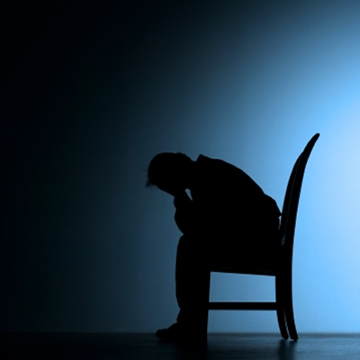

> We would like to know if there is a correlation between **major sport events** and **depression** within the winning country. We have chosen the 2018 FIFA World Cup and the country of France aka *le pays des Champions du Monde*.

> …and we got the data from Google Trends.

# Loading libraries

We will need `ggplot2`, `dplyr` and `hrbrthemes`.

```r
library(ggplot2)
library(dplyr)
library(hrbrthemes)
```

# Loading data

We also host the data file on our Github, if you want to [check that out](https://github.com/huanlebui/DataVizProject/blob/master/data.csv).

```r
data <- read.csv("data.csv")

data$week <- as.Date(data$week) # transform the date format into something more comfortable to handle with
```

# A quick look into the data

We actually had two seperate CSV files so we merged them into one. Under the `depression` and `cdm` attributes we have the trending levels of the keywords **depression** (in terms of search queries) and **coupe du monde** (in terms of occurrences in newsfeeds) respectively, throughout the year of 2018 in France.

```r
data
```

| week | depression | cdm |
| --- | --- | --- |
| 2018-01-07 | 82 | 0 |
| 2018-01-14 | 92 | 1 |
| 2018-01-21 | 96 | 1 |
| 2018-01-28 | 88 | 0 |
| 2018-02-04 | 82 | 1 |
| 2018-02-11 | 94 | 0 |
| 2018-02-18 | 90 | 1 |
| 2018-02-25 | 83 | 0 |
| 2018-03-04 | 100 | 1 |
| 2018-03-11 | 91 | 1 |

[output cut: 42 more lines]

# A primitive line chart

Let’s look at the trending levels of the two keywords in 2018.

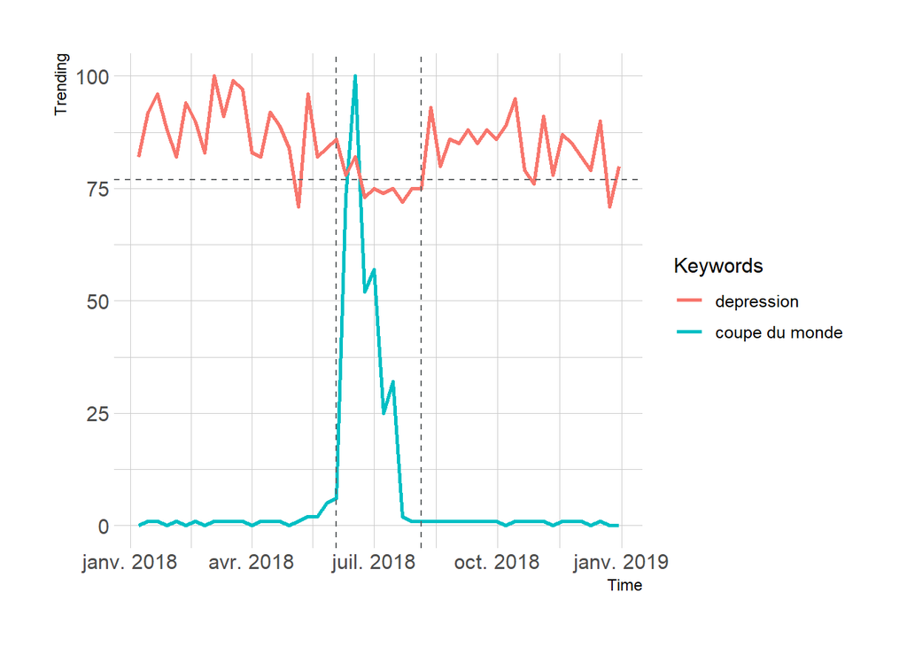

```r
data %>%
  ggplot( aes(x=week) ) +
    geom_line( aes(y = cdm, colour ="#e74c3c"), size = 1) + # cdm's trending curve
    geom_line( aes(y = depression, colour = "#c10000"), size = 1) + # depression's trending curve
    scale_color_discrete(name = "Keywords", labels = c("depression", "coupe du monde")) + # legends
    geom_hline(yintercept = 77, size = 0.5, color="#626567", linetype="dashed") + # to see more clearly the period of decrease of the keyword depression
    geom_vline(xintercept = as.Date("2018-06-03"), color="#626567", size = 0.5, linetype="dashed") + # to focus on the period of the world cup and slightly afterwards
    geom_vline(xintercept = as.Date("2018-08-05"), color="#626567", size = 0.5, linetype="dashed") +
    xlab("Time") +
    ylab("Trending") +
    theme_ipsum() # adding some theme
```

We can observe a slight decrease during a relatively long period of time for the keyword **depression** around the month of July. And of course we can easily notice the obvious skyrocketing keyword **coupe du monde** between June and July.

We chose this type of chart because these two events have their increase/decrease at the same period of time. But we admit that it is not perfect that’s why we will try something better.

# A bubble chart

As we just said, the line chart doesn’t help us see the correlation clearly. Now let’s plot some bubble chart to see how it goes.

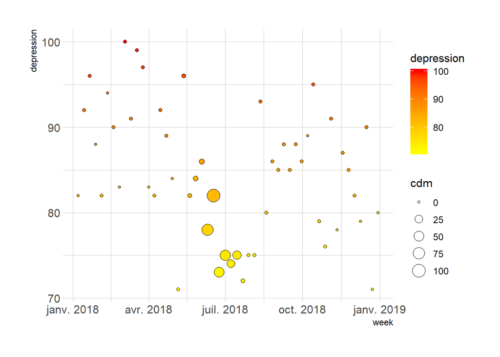

```r
#Bubble_graph
data %>%
  ggplot( aes(x=week,y=depression,fill=depression, size=cdm) ) + # cdm determines the size and depression determines the color (of the bubbles)
    geom_point(alpha=1, shape=21) +
    scale_fill_gradient(low="yellow", high="red")+
    theme_ipsum()
```

We confidently believe that this type of chart is the best to show the correlation.

# Conclusion

As everyone knows, **correlation** and **causation** (or causality) are not the same. These two events, the 2018 FIFA World Cup and the decrease of depression, can happen at the same time but it doesn’t mean that one has some effect on the other. If we want to have a thorough analysis, we would have to focus on other factors such as the weather, vacations, etc..

Anyway, one thing remains certain : on est les champions !

[figure not shown]